# Psychoinformatics - Week 4 (Exercises)

by 李采蓉 b08207042@ntu.edu.tw

```python
DEVELOPER_KEY = "AIzaSyCNo1zEyXqJ1CB0gjxIYRrXxdW94X3TIgI"
```

```python
from apiclient.discovery import build
import json

youtube = build('youtube', 'v3', developerKey=DEVELOPER_KEY)

result = youtube.videos().list(
    part='snippet,contentDetails,statistics',
    chart='mostPopular',
    regionCode='TW',maxResults=50).execute()

title = []
channelTitle = []
categoryId = []
viewCount = []
likeCount = []
dislikeCount = []
commentCount = []

for i in range(50):
        title.append(result['items'][i]['snippet']['title'])
        channelTitle.append(result['items'][i]['snippet']['channelTitle'])
        categoryId.append(result['items'][i]['snippet']['categoryId'])
        viewCount.append(result['items'][i]['statistics']['viewCount'])
        likeCount.append(result['items'][i]['statistics']['likeCount'])
        dislikeCount.append(result['items'][i]['statistics']['dislikeCount'])
        commentCount.append(result['items'][i]['statistics']['commentCount'])

youtube_dict = {'title':title, 'channelTitle': channelTitle,'categoryId':categoryId,
                'viewCount':viewCount,'likeCount':likeCount,'dislikeCount':dislikeCount, 'commentCount':commentCount}
```

```python
import pandas as pd
df = pd.DataFrame(youtube_dict)
df
```

|  | title | channelTitle | categoryId | viewCount | likeCount | dislikeCount | commentCount |
| --- | --- | --- | --- | --- | --- | --- | --- |
| 0 | 【盧秀芳辣晚報】3Q團隊喊"出狀況去監票" 狼來了? 刪Q成功 3Q:還有7天立委可做! 恐... | 中天新聞 | 25 | 372984 | 28591 | 236 | 484 |
| 1 | 【刪Q特報#LIVE】罷免陳柏惟開票直播特別報導 @中天新聞 20211023 | 中天新聞 | 25 | 369175 | 15199 | 379 | 211 |
| 2 | 【中天互動LIVE】"罷免陳柏惟" 就看今天 刪Q總部 "開票全記錄" 中天新聞現場直擊... | 中天電視 | 25 | 410253 | 12876 | 229 | 219 |
| 3 | 聽見玻璃心碎的聲音... 黃明志 Ft.陳芳語【玻璃心】@鬼才做音樂 2021 Ghosician | Namewee | 10 | 14667931 | 614226 | 15748 | 129773 |
| 4 | 【完整版上集】史上第一次! 成功罷免現任立委 "芒果乾"也救不了陳柏惟? TVBS戰情室 2... | 少康戰情室 | 25 | 291658 | 7007 | 421 | 1674 |
| 5 | 【#狗屎寫手】ＱＱㄋㄟㄋㄟ的出處｜#Chill革命 現場版｜ @喬瑟夫 ChillSeph | STR Network | 24 | 499606 | 19105 | 156 | 907 |
| 6 | 蔡英文救不了陳柏惟 罷免投票率52.63%史上最高! 預言蔡四大公投.罷林昶佐潰敗? 蔡到4... | 新聞大白話 | 25 | 499839 | 18717 | 270 | 400 |
| 7 | 陳柏惟vs.刪Q罷免案開票過程+結果出爐！陳柏惟大戰朱立倫江啟臣顏寬恒！台中二選區沙鹿區、龍... | 94要客訴 | 25 | 252120 | 1556 | 397 | 553 |
| 8 | 被「換臉」成謎片主角只能自認倒霉？Deep Fake 的傷害有多大？｜志祺七七 ft. 魚乾... | 志祺七七 X 圖文不符 | 22 | 503433 | 24675 | 484 | 3117 |
| 9 | 請不要對號入座... 黃明志 Ft.陳芳語【玻璃心】MV 製作花絮 | Namewee | 24 | 807875 | 47524 | 524 | 4215 |
| 10 | 陳柏惟:我沒輸 罷免過7天解職! 四大公投.罷林昶佐 民怨燒蔡英文? 蘇貞昌億來億去到處撒... | 國民大會 | 25 | 171425 | 9046 | 140 | 368 |
| 11 | SEVENTEEN (세븐틴) 'Rock with you' Official MV | HYBE LABELS | 10 | 14125781 | 902384 | 3633 | 135691 |
| 12 | 【正常發揮PiMW】降半旗"今天公祭" 嗨唱歌"3Q忘記“罷前之夜! 網集氣"送陳柏惟回高雄... | 正常發揮 | 25 | 227031 | 27852 | 316 | 1127 |
| 13 | 親哥哥在眼前竟然認不出來！生日慶生被整到不行！♥ 滴妹 | 滴妹 | 22 | 271325 | 8326 | 104 | 563 |
| 14 | 現代高中生的困擾 | 黃大謙 | 23 | 202297 | 9491 | 88 | 460 |
| 15 | 【中天互動LIVE】1023陳柏惟罷免投票日 中二選區含大肚.烏日.龍井.霧峰.沙鹿 最大投... | 中天電視 | 25 | 273056 | 7270 | 154 | 88 |
| 16 | 【中天直播#LIVE】向支持鄉親說3Q!下一步?陳柏惟:還沒想過!先一一向支持者說感謝 @中... | 中天電視 | 25 | 227303 | 6662 | 287 | 63 |
| 17 | TRASH 《離開台北 LEAVING TAIPEI》 Official Music Video | TRASH Band | 10 | 256263 | 8159 | 51 | 447 |
| 18 | 【LIVE】刪Q結果出爐！趙少康領軍分析陳柏惟罷免案 如何影響藍綠勢力消長？！ \| 2021... | 新聞大白話 | 25 | 170752 | 6801 | 151 | 185 |
| 19 | 陳柏惟罷免案最終結果！開票全解析！ft.黃暐瀚、董智森、陳揮文【#鄉民大會 特別節目】LIVE | 鄉民大會 | 25 | 284944 | 11137 | 184 | 660 |
| 20 | #玩很大七週年感謝祭 關於KID涉及在大馬路上跟鬼鬼吵架的重要聲明！開玩笑的啦～我們為了玩粉... | 綜藝玩很大 Mr.Player | 24 | 1332983 | 10922 | 367 | 1721 |
| 21 | 陳柏惟總統級造勢.警犬巡邏! 46死陳其邁不辭職只說不停止檢討! 公祭降半旗 蔡英文只停3分... | 新聞大白話 | 25 | 275771 | 15393 | 285 | 230 |
| 22 | 同意票超過罷免門檻 陳柏惟確定遭罷免！同意77899票vs.不同意73433票 關鍵一役結果... | 三立LIVE新聞 | 25 | 209675 | 1001 | 796 | 267 |
| 23 | 【FULL】兄弟团齐力寻找财富密码 他们能否带动R村完成“共同富裕”？《奔跑吧·黄河篇第二季... | 浙江卫视【奔跑吧】官方频道-欢迎订阅- | 24 | 322735 | 8114 | 199 | 1110 |
| 24 | 66歲高向鵬搶救第7天，兒子痛哭再曝病況！昏迷原因終於瞞不住！#高向鵬 #方怡萍 #茶娛飯後 | 茶娛飯後 | 1 | 348304 | 2217 | 171 | 0 |
| 25 | 【央視一分鐘】小玉涉「換臉」不雅片遭逮 黃明志.陳芳語MV《玻璃心》狠辱華｜眼球中央電視台 | 眼球中央電視台 | 25 | 608952 | 15382 | 788 | 1744 |
| 26 | 「你總是希望不斷前進，但感受是得停下來的。」- 這集突然變成 #謝盈萱 的諮商實境節目？ | 理科太太 Li Ke Tai Tai | 27 | 324370 | 14294 | 94 | 923 |
| 27 | 【正常發揮PiMW】綠議員逼"不念四個堅持就道歉"! 柯暴怒嗆:"網軍治國是民主自由?" 陳... | 正常發揮 | 25 | 182884 | 24896 | 201 | 804 |
| 28 | 【完整公開】LIVE 台中市選委會票數統計 陳柏惟罷免案「通過」 | 台視新聞 TTV NEWS | 25 | 113614 | 383 | 102 | 54 |
| 29 | 簡舒培逼覆誦蔡英文四個堅持！柯文哲爆氣怒吼「廢話不想唸」 反噹一句話秒讓她語塞｜中時新聞網 | 中時新聞網 | 25 | 696326 | 16412 | 807 | 9951 |
| 30 | DJ Snake, Ozuna, Megan Thee Stallion, LISA of ... | DJSnakeVEVO | 10 | 26360679 | 2946344 | 46583 | 274163 |
| 31 | [MV] IU(아이유) _ strawberry moon | 1theK (원더케이) | 24 | 11772446 | 946728 | 8810 | 42396 |
| 32 | You Don't Belong to Me ("More than Blue" TV Se... | Eric Chou - Topic | 10 | 107842 | 4873 | 25 | 0 |
| 33 | 小粉紅怒炸！〈玻璃心〉觀看暴衝600萬 黃明志再酸：留言符合主題｜鏡週刊 | 鏡週刊 | 25 | 444616 | 7819 | 249 | 2013 |
| 34 | 獨家專訪｜陳芳語震碎強國「玻璃心」 親回挨轟難相處、搶賺人民幣黑歷史 \| 台灣新聞 Taiw... | 蘋果新聞網 | 25 | 413511 | 9525 | 217 | 1966 |
| 35 | "台灣熱炒"飄香曼哈頓！思鄉遊子將"板凳.酒杯"帶入紐約 熱炒店充滿"台味"...開店一年登... | 從台灣看見世界的故事 | 25 | 804402 | 11990 | 342 | 1079 |
| 36 | 【豆漿&俊榮】 洗貓真的好煩阿阿阿阿 | 豆漿- SoybeanMilk | 15 | 441689 | 17271 | 91 | 1015 |
| 37 | 【央視一分鐘】網再掀黃明志陳芳語辱華歷史 NBA球星解放西藏 陸禁播賽爾提克賽事｜眼球中央電視台 | 眼球中央電視台 | 25 | 372229 | 9293 | 330 | 1740 |
| 38 | [최종회] '날 비춘 건 바로 너야' ♬Shine @COMPLETION MISSIO... | Mnet K-POP | 24 | 1812156 | 121127 | 993 | 6286 |
| 39 | 66歲高向鵬昏迷6天未醒，家人已做最壞打算，方怡萍嚇到生活停擺【娛樂星鮮事】#高向鵬#大牌哥... | 娛樂星鮮事 | 24 | 156587 | 1005 | 78 | 0 |
| 40 | 小玉「換臉」後製A片牟利千萬 訊後以50萬元交保｜鏡週刊 | 鏡週刊 | 24 | 274501 | 1096 | 161 | 546 |
| 41 | 盧廣仲 Crowd Lu【自我的介紹 in peace】Official Music Video | 添翼音樂 TEAM EAR MUSIC | 10 | 130540 | 4649 | 28 | 448 |
| 42 | 這群人 TGOP │那些爸媽曾經對你說過的謊 Lies Your Parents Told You | 這群人TGOP | 24 | 1132057 | 26756 | 478 | 1527 |
| 43 | 廢物莎莎挑戰「一週自律魔人」生活💪🏻身體竟然產生超神奇的變化…..｜愛莉莎莎Alisasa | 愛莉莎莎 Alisasa | 22 | 358664 | 13114 | 286 | 904 |
| 44 | 你們家裡也有情緒勒索的米蟲嗎？ \| Onion Man | Onion Man 洋蔥與阿文 第二短廢片頻道 | 1 | 124575 | 4096 | 864 | 669 |
| 45 | 【MV首播】楊哲 vs 謝宜君 - 你哪會不識我 (官方完整版MV) HD 【三立八點檔『天... | 豪記唱片 HCM Music | 10 | 75446 | 1559 | 47 | 79 |
| 46 | 跟唄姬穿搭風格互換！不可以色色！三蘆混血兒間的對決！Feat.@臺灣尋奇 唄姬【我是蕾菈I... | 我是蕾菈I'm Lyla | 22 | 191950 | 3746 | 61 | 196 |
| 47 | 2021 S11 英雄联盟全球总决赛 2021全球总决赛 S11八强淘汰赛 RNG v... | 联盟速递赛事频道 | 20 | 102345 | 221 | 36 | 17 |
| 48 | Brawl Stars: Brawl Talk - Lights, Camera, BRAWL! | Brawl Stars | 20 | 5548599 | 488405 | 4430 | 34202 |
| 49 | 【秘境探險】Uncharted官方預告 – 2022年2月11日-13日 搶先口碑場｜2月1... | Sony Pictures 索尼影業 | 24 | 416067 | 1503 | 39 | 290 |

## 1 Analyze what videos go viral? (8 points)

Please use [YouTube APIs](https://developers.google.com/youtube/v3/code_samples/python) to carry out a data-driven or hypothesis-driven microstudy about the characteristics of viral videos.

You need to present, here in this notebook, AT LEAST two **statistical** figures or tables as supporting evidence for your arguments. Each of these figures/tables deserves 4 points.

## 發燒影片種類

首先，我們先來了解Youtube發燒影片中以哪幾種影片為大宗。根據Youtube官方所給出的分類Id，我們可知Category Id會分別對應以下種類：

| ID | Category name |
| --- | --- |
| 1 | Film & Animation |
| 2 | Autos & Vehicles |
| 10 | Music |
| 15 | Pets & Animals |
| 17 | Sports |
| 19 | Travel & Events |
| 20 | Gaming |
| 22 | People & Blogs |
| 23 | Comedy |
| 24 | Entertainment |
| 25 | News & Politics |
| 26 | Howto & Style |
| 27 | Education |
| 28 | Science & Technology |
| 29 | Nonprofits & Activism |

```python
import matplotlib.pyplot as plt
```

```python
category = pd.DataFrame(df['categoryId'].value_counts().reset_index())
category.columns =['Id','num']
```

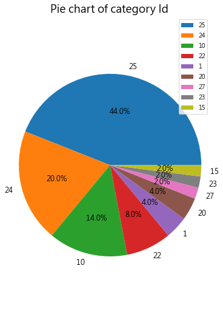

```python
plt.figure(figsize=(6,9))
plt.pie(category["num"],
        labels = category["Id"],
        autopct = "%1.1f%%",
        pctdistance = 0.6,
        textprops = {"fontsize" : 12},
        shadow=False)
plt.axis('equal')
plt.title("Pie chart of category Id", {"fontsize" : 18})
plt.legend(loc = "best")
plt.show()
```

由以上可看出，政治新聞類(25)為發燒影片大宗，共有22支影片，佔據50名的幾乎一半，且普遍排名都靠前，這可能與剛結束的陳柏惟罷免案有著密不可分的關係。

第三名為音樂類(10)，影片來源多元，無論中文、英文、韓文皆有上榜曲目，不難看出Youtube提供一個幾近無國界的平台，讓好的創作可以在世界流通。

### 政治新聞類影片的特徵

有鑑於政治新聞類影片為大宗，不免讓人好奇是否因昨日的罷免案受到社會關注才有此效果，這裡看一下陳柏惟的事到底有多少媒體報導，其背後立場又為何。

```python
PNdf = df[df['categoryId'].isin(['25'])]
PNdf2 = PNdf['title'].str.contains("柏惟","刪Q")
print(PNdf2.value_counts())
```

```
True     15
False     7
Name: title, dtype: int64
```

在22則政治新聞當中，便有15則(幾乎是$\frac{2}{3}$)為陳柏惟罷免案相關新聞，可見此事足以作為新聞吸引閱聽人。

```python
from matplotlib.font_manager import FontProperties
plt.rcParams['font.sans-serif'] = ['Microsoft JhengHei']
plt.rcParams['axes.unicode_minus'] = False
```

```python
filterPNdf = pd.DataFrame(PNdf[PNdf2])
category2 = pd.DataFrame(filterPNdf['channelTitle'].value_counts().reset_index())
category2.columns =['channel','num']
category2
```

|  | channel | num |
| --- | --- | --- |
| 0 | 新聞大白話 | 3 |
| 1 | 中天電視 | 3 |
| 2 | 正常發揮 | 2 |
| 3 | 少康戰情室 | 1 |
| 4 | 三立LIVE新聞 | 1 |
| 5 | 94要客訴 | 1 |
| 6 | 台視新聞 TTV NEWS | 1 |
| 7 | 中天新聞 | 1 |
| 8 | 國民大會 | 1 |
| 9 | 鄉民大會 | 1 |

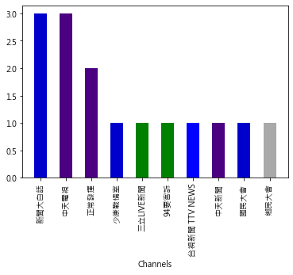

```python
plt.bar(category2.channel,
        category2.num,
        width=0.5,
        bottom=None,
        align='center',
        color=['mediumblue','indigo','indigo','mediumblue','green','green','blue','indigo', 'mediumblue', 'darkgrey'])
# 中天底下的頻道和節目用紫色單純因為我覺得它已經超越藍色，紅得發紫：）
plt.xticks(rotation='vertical')
plt.xlabel("Channels")
plt.show()
```

總的來說，時下熱門政治話題往往能獲得更高的關注，相關討論節目也更容易在短時間內成為發燒影片。

### Please submit this file to NTU COOL before next Monday (10/25).